# Practical Machine Learning - Course Project

Zannis Voulgaris

March 24, 2019

# Background

Using devices such as Jawbone Up, Nike FuelBand, and Fitbit it is now possible to collect a large amount of data about personal activity relatively inexpensively. These type of devices are part of the quantified self movement - a group of enthusiasts who take measurements about themselves regularly to improve their health, to find patterns in their behavior, or because they are tech geeks. One thing that people regularly do is quantify how much of a particular activity they do, but they rarely quantify how well they do it. In this project, your goal will be to use data from accelerometers on the belt, forearm, arm, and dumbell of 6 participants. They were asked to perform barbell lifts correctly and incorrectly in 5 different ways.

The goal of this project is to predict the manner in which they did the exercise. This is the “classe” variable in the training set.

# Data import,cleaning and preparation

## Essential packages

```r
library(caret);library(randomForest);library(gbm);library(rpart);library(rpart.plot);library(rattle)
```

## Import

```r
url.train <-"https://d396qusza40orc.cloudfront.net/predmachlearn/pml-training.csv"
url.valid <-"https://d396qusza40orc.cloudfront.net/predmachlearn/pml-testing.csv"
train.data <- read.csv(url(url.train))
valid.data <- read.csv(url(url.valid))
str(train.data)
```

```
## 'data.frame':    19622 obs. of  160 variables:
##  $ X                       : int  1 2 3 4 5 6 7 8 9 10 ...
##  $ user_name               : Factor w/ 6 levels "adelmo","carlitos",..: 2 2 2 2 2 2 2 2 2 2 ...
##  $ raw_timestamp_part_1    : int  1323084231 1323084231 1323084231 1323084232 1323084232 1323084232 1323084232 1323084232 1323084232 1323084232 ...
##  $ raw_timestamp_part_2    : int  788290 808298 820366 120339 196328 304277 368296 440390 484323 484434 ...
##  $ cvtd_timestamp          : Factor w/ 20 levels "02/12/2011 13:32",..: 9 9 9 9 9 9 9 9 9 9 ...
##  $ new_window              : Factor w/ 2 levels "no","yes": 1 1 1 1 1 1 1 1 1 1 ...
##  $ num_window              : int  11 11 11 12 12 12 12 12 12 12 ...
##  $ roll_belt               : num  1.41 1.41 1.42 1.48 1.48 1.45 1.42 1.42 1.43 1.45 ...
##  $ pitch_belt              : num  8.07 8.07 8.07 8.05 8.07 8.06 8.09 8.13 8.16 8.17 ...
##  $ yaw_belt                : num  -94.4 -94.4 -94.4 -94.4 -94.4 -94.4 -94.4 -94.4 -94.4 -94.4 ...
##  $ total_accel_belt        : int  3 3 3 3 3 3 3 3 3 3 ...
##  $ kurtosis_roll_belt      : Factor w/ 397 levels "","-0.016850",..: 1 1 1 1 1 1 1 1 1 1 ...
##  $ kurtosis_picth_belt     : Factor w/ 317 levels "","-0.021887",..: 1 1 1 1 1 1 1 1 1 1 ...
##  $ kurtosis_yaw_belt       : Factor w/ 2 levels "","#DIV/0!": 1 1 1 1 1 1 1 1 1 1 ...
```

[output cut: 86 more lines]

```r
str(valid.data)
```

```
## 'data.frame':    20 obs. of  160 variables:
##  $ X                       : int  1 2 3 4 5 6 7 8 9 10 ...
##  $ user_name               : Factor w/ 6 levels "adelmo","carlitos",..: 6 5 5 1 4 5 5 5 2 3 ...
##  $ raw_timestamp_part_1    : int  1323095002 1322673067 1322673075 1322832789 1322489635 1322673149 1322673128 1322673076 1323084240 1322837822 ...
##  $ raw_timestamp_part_2    : int  868349 778725 342967 560311 814776 510661 766645 54671 916313 384285 ...
##  $ cvtd_timestamp          : Factor w/ 11 levels "02/12/2011 13:33",..: 5 10 10 1 6 11 11 10 3 2 ...
##  $ new_window              : Factor w/ 1 level "no": 1 1 1 1 1 1 1 1 1 1 ...
##  $ num_window              : int  74 431 439 194 235 504 485 440 323 664 ...
##  $ roll_belt               : num  123 1.02 0.87 125 1.35 -5.92 1.2 0.43 0.93 114 ...
##  $ pitch_belt              : num  27 4.87 1.82 -41.6 3.33 1.59 4.44 4.15 6.72 22.4 ...
##  $ yaw_belt                : num  -4.75 -88.9 -88.5 162 -88.6 -87.7 -87.3 -88.5 -93.7 -13.1 ...
##  $ total_accel_belt        : int  20 4 5 17 3 4 4 4 4 18 ...
##  $ kurtosis_roll_belt      : logi  NA NA NA NA NA NA ...
##  $ kurtosis_picth_belt     : logi  NA NA NA NA NA NA ...
##  $ kurtosis_yaw_belt       : logi  NA NA NA NA NA NA ...
```

[output cut: 86 more lines]

## Cleaning

```r
train.clean <-train.data[,!sapply(train.data,function(x) any(is.na(x)))]
valid.clean <-valid.data[,!sapply(valid.data,function(x) any(is.na(x)))]
train.clean <- train.clean[,-c(1:7)]
valid.clean <- valid.clean[,-c(1:7)]
dim(train.clean);dim(valid.clean)
```

```
## [1] 19622    86
```

```
## [1] 20 53
```

Post-cleaning process, training dataset contains 86 variables and validation dataset 53 variables respectively.

## Data preparation for prediction purposes

In order to prepare data for prediction, we created 2 distinct partitions, splitting the ‘clean’ training dataset into 70% sub-train data and 30% test data, of which the latter will serve for the computation of out-of-sample errors. We also remove near-zero variance variables.

```r
set.seed(123)
inTrain <- createDataPartition(train.clean$classe,p=0.7,list=FALSE)
training <- train.clean[inTrain,]
testing <- train.clean[-inTrain,]
flagnzv <- nearZeroVar(training)
flagnzv
```

```
##  [1]  5  6  7  8  9 10 11 12 13 36 37 38 39 40 41 45 46 47 48 49 50 51 52
## [24] 53 67 68 69 70 71 72 73 74 75
```

```r
training <- training[,-flagnzv]
testing <- testing[,-flagnzv]
dim(training);dim(testing)
```

```
## [1] 13737    53
```

```
## [1] 5885   53
```

After the removal of near-zero variance variables, train & test datasets contain 53 variables.

Furthermore, we will examine 3 different classification models: 1. Clasification Trees 2. Random Forest 3. Gradient Boosting

In order to have an unbiased measurement of the out of sample accuracy of the model, we opted for a 5-fold cross validation, applicable to each model.

# Prediction

## Prediction with classification trees

[figure not shown]

```r
treeFit <- train(classe~., data=training, method="rpart", trControl=trainControl(method="cv", number=5))
fancyRpartPlot(treeFit$finalModel)
```

```r
pred.treeFit <- predict(treeFit,newdata=testing)
cm.treeFit<-confusionMatrix(pred.treeFit,testing$classe)
cm.treeFit$overall['Accuracy']
```

```
##  Accuracy
## 0.5522515
```

We notice a less than satisfactory accuracy circa 55%, which abstains the deployment of this model, as the outcome variable will not be predicted accurately by these predictors.

## Prediction with random forest

```r
rfFit <- train(classe~., data=training, method="rf", trControl=trainControl(method="cv", number=5))
print(rfFit)
```

```
## Random Forest
##
## 13737 samples
##    52 predictor
##     5 classes: 'A', 'B', 'C', 'D', 'E'
##
## No pre-processing
## Resampling: Cross-Validated (5 fold)
## Summary of sample sizes: 10990, 10989, 10991, 10989, 10989
## Resampling results across tuning parameters:
##
##   mtry  Accuracy   Kappa
##    2    0.9894442  0.9866466
##   27    0.9908276  0.9883972
##   52    0.9859504  0.9822290
##
## Accuracy was used to select the optimal model using the largest value.
## The final value used for the model was mtry = 27.
```

```r
rfFit$finalModel
```

```
##
## Call:
##  randomForest(x = x, y = y, mtry = param$mtry)
##                Type of random forest: classification
##                      Number of trees: 500
## No. of variables tried at each split: 27
##
##         OOB estimate of  error rate: 0.69%
## Confusion matrix:
##      A    B    C    D    E class.error
## A 3902    3    0    0    1 0.001024066
## B   21 2630    6    1    0 0.010534236
## C    0   15 2374    7    0 0.009181970
## D    0    1   26 2223    2 0.012877442
## E    0    1    4    7 2513 0.004752475
```

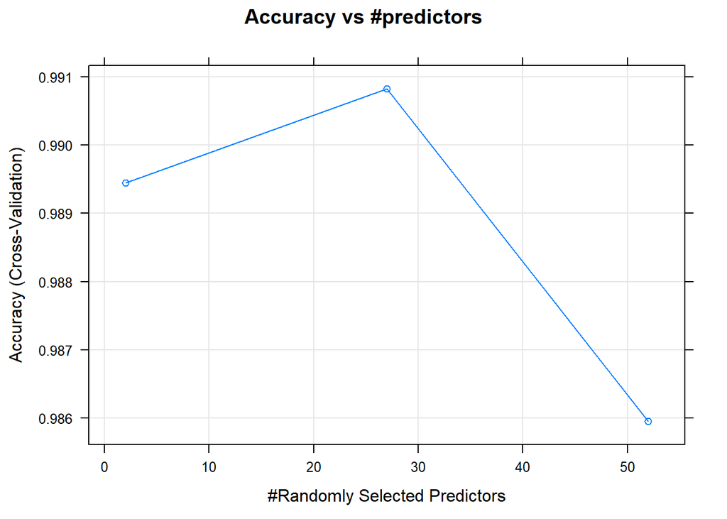

```r
plot(rfFit,main="Accuracy vs #predictors")
```

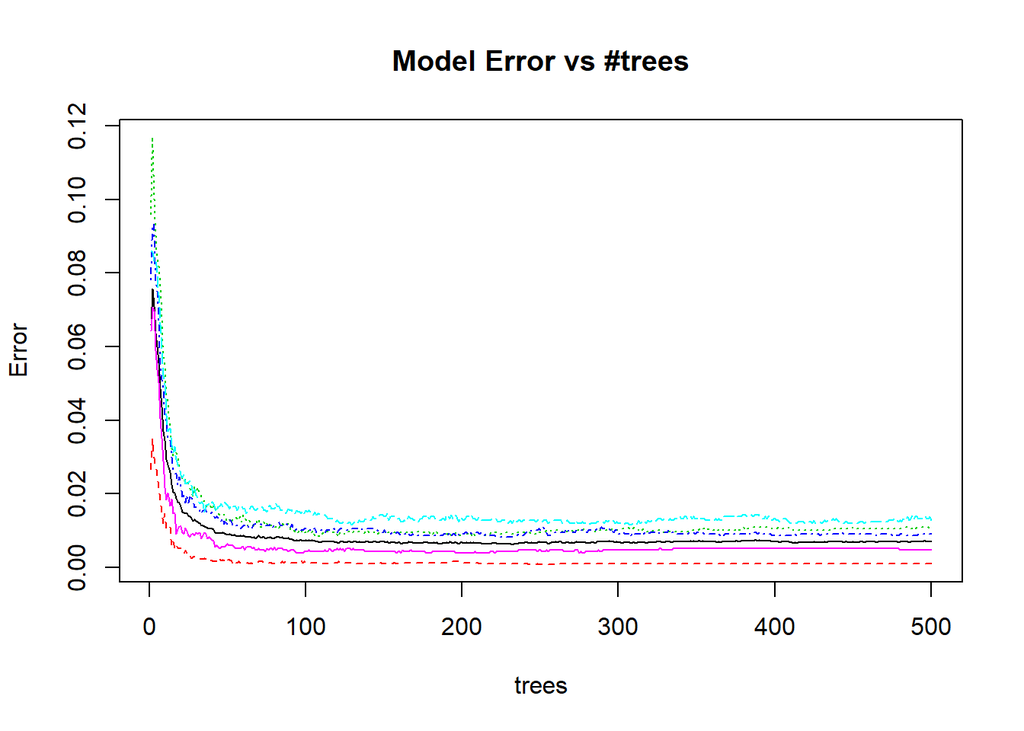

```r
plot(rfFit$finalModel,main="Model Error vs #trees")
```

```r
pred.rfFit <- predict(rfFit,newdata=testing)
cm.rfFit<-confusionMatrix(pred.rfFit,testing$classe)
cm.rfFit$overall['Accuracy']
```

```
##  Accuracy
## 0.9932031
```

```r
varImp(rfFit)
```

```
## rf variable importance
##
##   only 20 most important variables shown (out of 52)
##
##                      Overall
## roll_belt             100.00
## pitch_forearm          58.82
## yaw_belt               55.73
## pitch_belt             43.60
## magnet_dumbbell_y      42.84
## magnet_dumbbell_z      42.67
## roll_forearm           40.58
## accel_dumbbell_y       20.63
## roll_dumbbell          19.19
## accel_forearm_x        17.60
## magnet_dumbbell_x      17.04
## magnet_belt_z          14.96
## accel_dumbbell_z       14.14
## accel_belt_z           13.36
## magnet_belt_y          13.21
## magnet_forearm_z       13.14
## total_accel_dumbbell   12.66
## gyros_belt_z           11.76
## yaw_arm                10.76
## magnet_belt_x          10.18
```

With random forest model, we notice an almost optimal accuracy, circa 99%. The optimal number of predictors amount to 27, as adding more predictors significantly increases model complexity without improving model accuracy.

## Prediction with gradient boosting

```r
gbmFit <- train(classe~., data=training, method="gbm", trControl=trainControl(method="cv", number=5), verbose=FALSE)
print(gbmFit)
```

```
## Stochastic Gradient Boosting
##
## 13737 samples
##    52 predictor
##     5 classes: 'A', 'B', 'C', 'D', 'E'
##
## No pre-processing
## Resampling: Cross-Validated (5 fold)
## Summary of sample sizes: 10989, 10990, 10989, 10991, 10989
## Resampling results across tuning parameters:
##
##   interaction.depth  n.trees  Accuracy   Kappa
##   1                   50      0.7494358  0.6823726
##   1                  100      0.8191761  0.7711431
##   1                  150      0.8501873  0.8104196
##   2                   50      0.8524435  0.8130935
##   2                  100      0.9046389  0.8793268
##   2                  150      0.9297532  0.9111029
##   3                   50      0.8954658  0.8676600
##   3                  100      0.9395807  0.9235392
##   3                  150      0.9595258  0.9487944
##
## Tuning parameter 'shrinkage' was held constant at a value of 0.1
##
## Tuning parameter 'n.minobsinnode' was held constant at a value of 10
## Accuracy was used to select the optimal model using the largest value.
## The final values used for the model were n.trees = 150,
##  interaction.depth = 3, shrinkage = 0.1 and n.minobsinnode = 10.
```

```r
gbmFit$finalModel
```

```
## A gradient boosted model with multinomial loss function.
## 150 iterations were performed.
## There were 52 predictors of which 40 had non-zero influence.
```

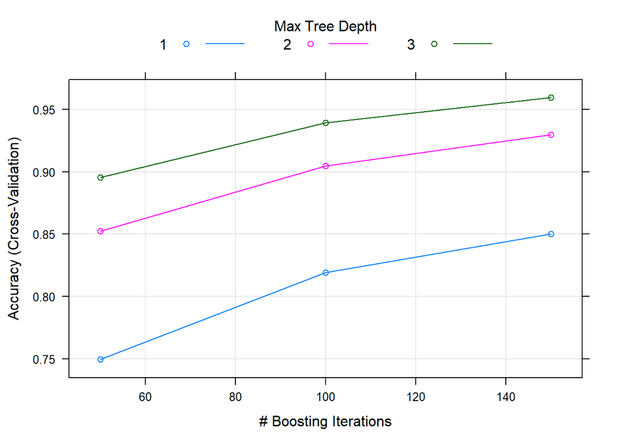

```r
plot(gbmFit)
```

```r
pred.gbmFit <- predict(gbmFit,newdata=testing)
cm.gbmFit<-confusionMatrix(pred.gbmFit,testing$classe)
cm.gbmFit$overall['Accuracy']
```

```
##  Accuracy
## 0.9593883
```

```r
varImp(gbmFit)
```

```
## gbm variable importance
##
##   only 20 most important variables shown (out of 52)
##
##                   Overall
## roll_belt         100.000
## pitch_forearm      55.132
## yaw_belt           36.126
## magnet_dumbbell_z  34.015
## magnet_dumbbell_y  25.660
## roll_forearm       24.015
## magnet_belt_z      21.575
## pitch_belt         18.858
## gyros_belt_z       13.726
## accel_forearm_x    13.278
## roll_dumbbell      12.554
## accel_dumbbell_y   10.599
## gyros_dumbbell_y   10.112
## magnet_forearm_z    8.011
## accel_dumbbell_x    6.931
## accel_forearm_z     6.338
## magnet_belt_y       6.270
## yaw_arm             6.236
## magnet_dumbbell_x   5.564
## magnet_forearm_x    5.552
```

Boosting model precision is significant (circa 96%), however it falls short of the random forest model result, which will ultimately serve as the preferred go-to model for our final prediction.

# Final Prediction

```r
Final.Pred <-predict(rfFit,newdata=valid.clean)
Final.Pred
```

```
##  [1] B A B A A E D B A A B C B A E E A B B B
## Levels: A B C D E
```

We used the random forest model to predict the value of ‘classe’, deploying the prescribed validation data set.